# Exploring Netflix Content Patterns: An Analytical Approach Using Metadata

### Now for TV Shows

Apply PCA and Record the Silhouette Score

This has been done as shown in your code snippet, with a resulting silhouette score which provides a benchmark for comparison. Apply KPCA for Different Sigma Values

Using the RBF kernel, vary sigma from 0.002 to 2 in increments of 0.1, and perform KMeans clustering on the KPCA-transformed data to calculate silhouette scores for each configuration. Plot Silhouette Scores for KPCA

Compare these scores with the baseline PCA score to determine if KPCA offers any improvement.

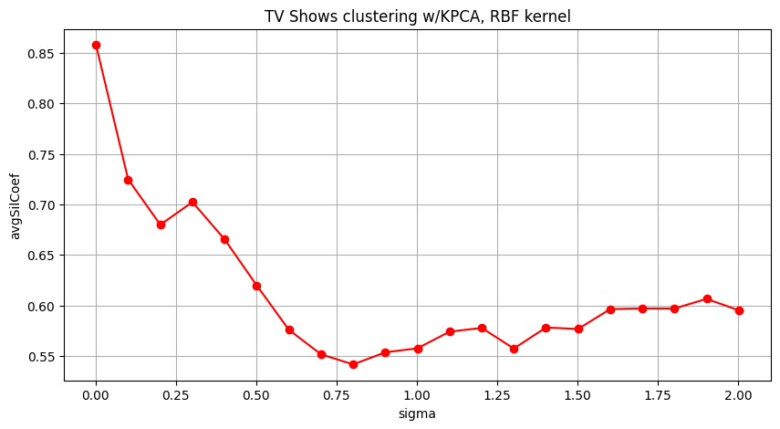

```
PCA Silhouette Score: 0.668
```

```python
import numpy as np
import pandas as pd
from sklearn.decomposition import KernelPCA
from sklearn.cluster import KMeans
from sklearn.metrics import silhouette_score
import matplotlib.pyplot as plt

# Assuming 'scaled_tv_show_features' is already scaled features of the TV shows data

# Sigma values range from 0.002 to 2, in increments of 0.1
sigmas = np.arange(0.002, 2.1, 0.1)
silhouette_scores_kpca = []

for sigma in sigmas:
    gamma = 1 / (2 * sigma ** 2)  # Convert sigma to gamma for the RBF kernel
    kpca_tv = KernelPCA(n_components=2, kernel='rbf', gamma=gamma)
    kernel_principal_components_tv = kpca_tv.fit_transform(scaled_tv_show_features)

    # KMeans clustering on the KPCA results
    tv_show_kmeans_kpca = KMeans(n_clusters=3, n_init=10, random_state=42)
    tv_show_kmeans_kpca.fit(kernel_principal_components_tv)

    # Compute Silhouette Score
    score_kpca = silhouette_score(kernel_principal_components_tv, tv_show_kmeans_kpca.labels_)
    silhouette_scores_kpca.append(score_kpca)

# Plotting the silhouette coefficient versus sigma for KPCA
plt.figure(figsize=(10, 5))
plt.plot(sigmas, silhouette_scores_kpca, 'o-', color='red')
plt.title("TV Shows clustering w/KPCA, RBF kernel")
plt.xlabel("sigma")
plt.ylabel("avgSilCoef")
plt.grid(True)
plt.show()

# Print PCA Silhouette Score for comparison
print(f"PCA Silhouette Score: {silhouette_avg_tv:.3f}")
```

```python
!pip install mlxtend==0.23.3
```

[output not shown]

## Netflix Recommender System

### Content Based Recommender System

```python
from sklearn.feature_extraction.text import TfidfVectorizer
from sklearn.metrics.pairwise import cosine_similarity

# Combine relevant features into a single string
def combine_features(row):
    return f"{row['type']} {row['director']} {' '.join(row['cast'].split(', '))} {row['country']} {row['rating']}"

# Update the combine_features function to handle missing or non-string values
def combine_features(row):
    return f"{str(row['type'])} {str(row['director'])} {' '.join(str(row['cast']).split(', ') if isinstance(row['cast'], str) else ['Unknown'])} {str(row['country'])} {str(row['rating'])}"

# Apply the function to create the 'combined_features' column
netflix_data['combined_features'] = netflix_data.apply(combine_features, axis=1)

# Check if the 'combined_features' column was created correctly
print(netflix_data[['title', 'combined_features']].head())

# Create a combined features column
netflix_data['combined_features'] = netflix_data.apply(combine_features, axis=1)

# Convert the combined features into TF-IDF vectors
tfidf = TfidfVectorizer(stop_words='english')
tfidf_matrix = tfidf.fit_transform(netflix_data['combined_features'])

# Compute cosine similarity matrix
cosine_sim = cosine_similarity(tfidf_matrix, tfidf_matrix)

print("Shape of Cosine Similarity Matrix:", cosine_sim.shape)
```

```
                   title                                  combined_features
0   Dick Johnson Is Dead  Movie Kirsten Johnson Unknown United States PG-13
1          Blood & Water  TV Show Unknown Ama Qamata Khosi Ngema Gail Ma...
2              Ganglands  TV Show Julien Leclercq Sami Bouajila Tracy Go...
3  Jailbirds New Orleans              TV Show Unknown Unknown Unknown TV-MA
4           Kota Factory  TV Show Unknown Mayur More Jitendra Kumar Ranj...
Shape of Cosine Similarity Matrix: (8790, 8790)
```

### Recommender System Function

```
Recommended Titles:
                                                  title     type rating  \
5200                             Beyond Stranger Things  TV Show  TV-14
1127                                   Prank Encounters  TV Show  TV-MA
1195  Operation Varsity Blues: The College Admission...    Movie      R
8476                        The Real Football Factories  TV Show  TV-MA
5594                    Trevor Noah: Afraid of the Dark    Movie  TV-14
4377                       Trevor Noah: Son of Patricia    Movie  TV-MA
3398                                                Eli    Movie  TV-MA
7193                              Kicking and Screaming    Movie      R
6606                 Diana: 7 Days That Shook the World    Movie  TV-PG
8697                                    War on Everyone    Movie      R

      release_year   duration         country  similarity_score
5200          2017   1 Season   United States          0.686167
1127          2021  2 Seasons   United States          0.300895
1195          2021    100 min   United States          0.197121
8476          2006   1 Season  United Kingdom          0.155618
5594          2017     67 min   United States          0.149262
4377          2018     64 min   United States          0.139583
3398          2019     98 min   United States          0.131298
7193          1995     97 min   United States          0.123951
6606          2017     93 min  United Kingdom          0.117401
8697          2016     98 min  United Kingdom          0.115766
```

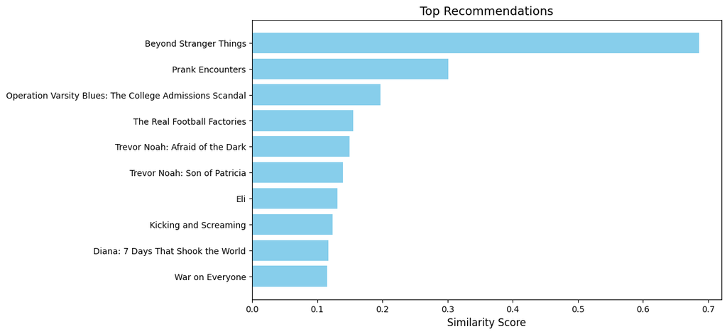

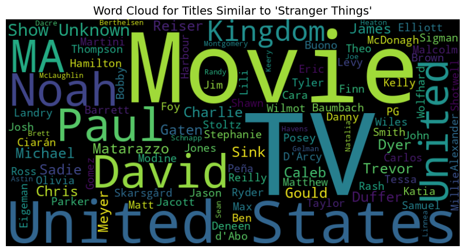

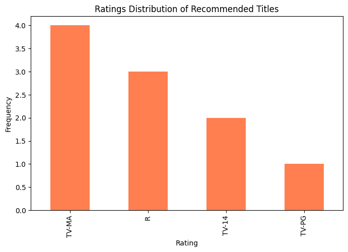

```
Exiting the recommender system. Goodbye!
```

```python
import pandas as pd
import matplotlib.pyplot as plt
from wordcloud import WordCloud
from sklearn.feature_extraction.text import TfidfVectorizer
from sklearn.metrics.pairwise import cosine_similarity

# Combine features into a single column
def combine_features(row):
    return f"{str(row['type'])} {str(row['director'])} {' '.join(str(row['cast']).split(', ') if isinstance(row['cast'], str) else ['Unknown'])} {str(row['country'])} {str(row['rating'])}"

netflix_data['combined_features'] = netflix_data.apply(combine_features, axis=1)

# TF-IDF vectorization
tfidf = TfidfVectorizer(stop_words='english')
tfidf_matrix = tfidf.fit_transform(netflix_data['combined_features'])

# Compute cosine similarity
cosine_sim = cosine_similarity(tfidf_matrix, tfidf_matrix)

# Recommender function
def recommend(title, cosine_sim, data):
    try:
        idx = data[data['title'].str.lower() == title.lower()].index[0]
        sim_scores = list(enumerate(cosine_sim[idx]))
        sim_scores = sorted(sim_scores, key=lambda x: x[1], reverse=True)
        sim_indices = [i[0] for i in sim_scores[1:11]]
        recommendations = data.iloc[sim_indices][['title', 'type', 'rating', 'release_year', 'duration', 'country']]
        recommendations['similarity_score'] = [sim_scores[i][1] for i in range(1, 11)]
        return recommendations
    except IndexError:
        return f"'{title}' not found in the dataset. Please check your input."

# Visualize Recommendations
def visualize_recommendations(recommendations):
    plt.figure(figsize=(10, 6))
    plt.barh(recommendations['title'], recommendations['similarity_score'], color='skyblue')
    plt.xlabel('Similarity Score', fontsize=12)
    plt.title('Top Recommendations', fontsize=14)
    plt.gca().invert_yaxis()  # Invert Y-axis for ranking
    plt.show()

# Generate Word Cloud
def generate_wordcloud(title, data):
    try:
        idx = data[data['title'].str.lower() == title.lower()].index[0]
        similar_indices = cosine_similarity(tfidf_matrix[idx], tfidf_matrix).argsort()[0, -11:-1]
        similar_data = data.iloc[similar_indices]
        text = ' '.join(similar_data['combined_features'])
        wordcloud = WordCloud(width=800, height=400, background_color='black').generate(text)

        plt.figure(figsize=(10, 6))
        plt.imshow(wordcloud, interpolation='bilinear')
        plt.axis('off')
        plt.title(f"Word Cloud for Titles Similar to '{title}'", fontsize=14)
        plt.show()
    except IndexError:
        print(f"'{title}' not found in the dataset. Please check your input.")

# Ratings Distribution
def ratings_distribution(recommendations):
    plt.figure(figsize=(8, 5))
    recommendations['rating'].value_counts().plot(kind='bar', color='coral')
    plt.title("Ratings Distribution of Recommended Titles")
    plt.xlabel("Rating")
    plt.ylabel("Frequency")
    plt.show()

# Interactive User Input
while True:
    user_input = input("Enter a movie or TV show title (or 'exit' to quit): ").strip()
    if user_input.lower() == 'exit':
        print("Exiting the recommender system. Goodbye!")
        break

    recommendations = recommend(user_input, cosine_sim, netflix_data)
    if isinstance(recommendations, str):  # Handle missing titles
        print(recommendations)
        continue

    # Display recommendations
    print("\nRecommended Titles:")
    print(recommendations)

    # Visualize recommendations
    visualize_recommendations(recommendations)

    # Generate a word cloud for metadata of similar titles
    generate_wordcloud(user_input, netflix_data)

    # Show ratings distribution of recommendations
    ratings_distribution(recommendations)

    print("\n")
```